# 海龟交易法 System 1 + 2N ATR 止损 + 分批加仓（紫金矿业）

策略骨架：

- 入场：收盘价突破 **20 日 Donchian 高点** → T+1 建仓 1 份
- 加仓：close ≥ 最后入场价 + **0.5·N** → T+1 再加 1 份，最多 5 份
- 平仓：close 跌破 **10 日 Donchian 低点** 或 **止损位（入场价 − 2·N）**
- 仓位：5 份 × 20% = 100% 上限，不带杠杆
- 周期 ATR(20)；持有期内止损只升不降

回测区间 2025-07-04 ~ 2026-07-03 共 242 个交易日。末尾「参数实验」section 用通道 15 日 + 加仓 2 次重跑一次。

## 0. 数据来源与依赖

- 日线 CSV：`data/zijin_daily_1y.csv`（Tushare Pro 取数；字段 trade_date/open/high/low/close 等）
- Python 依赖：numpy / pandas / matplotlib（项目内 Anaconda 3.11）

```python
import os
from pathlib import Path

import numpy as np
import pandas as pd
import matplotlib.pyplot as plt

plt.rcParams["font.sans-serif"] = ["Microsoft YaHei", "SimHei"]
plt.rcParams["axes.unicode_minus"] = False

PROJECT_DIR = Path.cwd()
if PROJECT_DIR.name == "strategies":
    PROJECT_DIR = PROJECT_DIR.parent
DATA_DIR = PROJECT_DIR / "data"
CSV_PATH = DATA_DIR / "zijin_daily_1y.csv"
OUT_PNG = DATA_DIR / "zijin_turtle_donchian.png"
OUT_PNG_EXP = DATA_DIR / "zijin_turtle_donchian_exp.png"
print("PROJECT_DIR =", PROJECT_DIR)
print("CSV exists  =", CSV_PATH.exists())
```

```
PROJECT_DIR = D:\代码\量化Workshop
CSV exists  = True
```

```python
# 海龟参数（主流程：原始值）
ENTRY_N = 20          # 入场 Donchian 通道周期
EXIT_N = 10           # 出场 Donchian 通道周期
ATR_N = 20            # ATR 周期
ATR_MULT = 2.0        # 止损倍数（入场价 − ATR_MULT × N）
MAX_UNITS = 5         # 单方向最多份数（1 入场 + 4 加仓）
UNIT_SIZE = 1 / MAX_UNITS  # 每份占资金比例
ADD_TRIGGER = 0.5     # 加仓触发：最后入场价 + ADD_TRIGGER × N
COMMISSION = 0.0003   # 单边手续费（含佣金，万三）
SLIPPAGE = 0.0        # 滑点
ANN_FACTOR = 252      # 年化因子

(ENTRY_N, EXIT_N, ATR_N, ATR_MULT, MAX_UNITS, ADD_TRIGGER, UNIT_SIZE)
```

```
(20, 10, 20, 2.0, 5, 0.5, 0.2)
```

## 1. 数据读入与真实波动幅度（TR）

```python
def load_data(path):
    df = pd.read_csv(path)
    df["trade_date"] = pd.to_datetime(df["trade_date"])
    df = df.sort_values("trade_date").reset_index(drop=True)
    return df

def true_range(df):
    high, low, prev_close = df["high"], df["low"], df["close"].shift(1)
    tr = pd.concat(
        [high - low,
         (high - prev_close).abs(),
         (low - prev_close).abs()],
        axis=1,
    ).max(axis=1)
    tr.iloc[0] = high.iloc[0] - low.iloc[0]
    return tr

raw = load_data(CSV_PATH)
print(f"载入 {len(raw)} 行：从 {raw['trade_date'].iloc[0].date()} 到 {raw['trade_date'].iloc[-1].date()}")
raw.head(3)
```

```
载入 242 行：从 2025-07-04 到 2026-07-03
```

|  | ts_code | trade_date | open | high | low | close | pre_close | change | pct_chg | vol | amount |
| --- | --- | --- | --- | --- | --- | --- | --- | --- | --- | --- | --- |
| 0 | 601899.SH | 2025-07-04 | 20.07 | 20.29 | 19.84 | 20.05 | 20.29 | -0.24 | -1.1828 | 1358556.26 | 2725507.573 |
| 1 | 601899.SH | 2025-07-07 | 19.96 | 20.02 | 19.71 | 19.80 | 20.05 | -0.25 | -1.2469 | 834674.74 | 1658374.033 |
| 2 | 601899.SH | 2025-07-08 | 19.87 | 20.04 | 19.75 | 19.82 | 19.80 | 0.02 | 0.1010 | 970733.77 | 1928723.033 |

## 2. 信号状态机：首入 / 加仓 / 平仓（含 2N 止损）

```python
def build_signals(df, entry_n, exit_n, atr_n, atr_mult,
                  max_units, unit_size, add_trigger):
    df = df.copy()

    df["upper_entry"] = df["high"].rolling(entry_n).max().shift(1)
    df["lower_exit"] = df["low"].rolling(exit_n).min().shift(1)
    df["lower_full"] = df["low"].rolling(entry_n).min().shift(1)
    df["atr"] = true_range(df).rolling(atr_n).mean()

    upper = df["upper_entry"].values
    lower = df["lower_exit"].values
    close = df["close"].values
    atr_v = df["atr"].values

    n = len(df)
    units_series = np.zeros(n, dtype=int)
    position = np.zeros(n)
    sl_series = np.full(n, np.nan)
    event = np.array([""] * n, dtype=object)

    units = 0
    entry_prices, highest_entry, sl_price = [], np.nan, np.nan

    for i in range(n):
        u, l, c, a = upper[i], lower[i], close[i], atr_v[i]
        if np.isnan(u) or np.isnan(l) or np.isnan(a):
            units_series[i] = 0
            continue
        event_today = ""

        # 1) 平仓（优先）
        if units > 0:
            hit_exit = c < l
            hit_stop = (not np.isnan(sl_price)) and (c <= sl_price)
            if hit_exit or hit_stop:
                units = 0
                entry_prices = []
                highest_entry = np.nan
                sl_price = np.nan
                event_today = "exit_signal" if hit_exit else "exit_stop"

        # 2) 入场（空仓 + 突破 20 日高）
        if units == 0 and c > u:
            units = 1
            entry_prices = [c]
            highest_entry = c
            sl_price = c - atr_mult * a
            if not event_today:
                event_today = "entry"

        # 3) 加仓（持仓未满 + close ≥ 最后入场价 + 0.5·N）
        elif units > 0 and units < max_units:
            last_entry = entry_prices[-1]
            trigger_price = last_entry + add_trigger * a
            if c >= trigger_price:
                units += 1
                entry_prices.append(c)
                highest_entry = max(highest_entry, c)
                new_sl = highest_entry - atr_mult * a
                sl_price = new_sl if np.isnan(sl_price) else max(sl_price, new_sl)
                if not event_today:
                    event_today = "add"

        units_series[i] = units
        position[i] = units * unit_size
        if units > 0:
            sl_series[i] = sl_price
        event[i] = event_today

    df["units"] = units_series
    df["signal"] = (units_series > 0).astype(int)
    df["stop_loss"] = pd.Series(sl_series, index=df.index)
    df["event"] = event
    df["position"] = pd.Series(position, index=df.index).shift(1).fillna(0)
    return df
```

## 3. T+1 回测与指标（含日均、标准差、最大回撤起止日）

```python
def backtest(df, commission, slippage):
    df = df.copy()
    df["ret"] = df["close"].pct_change().fillna(0)
    df["strat_ret"] = df["position"] * df["ret"]
    df["trade_units"] = (df["position"].diff() / UNIT_SIZE).abs().fillna(0)
    df["cost"] = df["trade_units"] * (commission + slippage)
    df["strat_ret_net"] = df["strat_ret"] - df["cost"]
    df["nav_strategy"] = (1 + df["strat_ret_net"]).cumprod()
    df["nav_buy_hold"] = (1 + df["ret"]).cumprod()
    return df


def compute_metrics(df):
    nav = df["nav_strategy"]
    bh = df["nav_buy_hold"]
    daily = df["strat_ret_net"]

    final_nav = nav.iloc[-1]
    total_ret = final_nav / nav.iloc[0] - 1
    bh_ret = bh.iloc[-1] / bh.iloc[0] - 1
    n = len(df)
    mean_daily = daily.mean()
    std_daily = daily.std()
    ann_ret = (1 + total_ret) ** (ANN_FACTOR / n) - 1
    ann_vol = std_daily * np.sqrt(ANN_FACTOR)
    sharpe = mean_daily / std_daily * np.sqrt(ANN_FACTOR) if std_daily > 0 else np.nan

    running_max = nav.cummax()
    drawdown = nav / running_max - 1
    max_dd = drawdown.min()
    trough_idx = drawdown.idxmin()
    peak_idx = nav.iloc[: trough_idx + 1].idxmax()
    peak_date = df["trade_date"].iloc[peak_idx]
    trough_date = df["trade_date"].iloc[trough_idx]

    evt = df["event"]
    return {
        "n": n,
        "final_nav": final_nav,
        "累计回报": total_ret,
        "买入持有回报": bh_ret,
        "日均收益": mean_daily,
        "日收益标准差": std_daily,
        "年化收益": ann_ret,
        "年化波动": ann_vol,
        "夏普比率": sharpe,
        "最大回撤": max_dd,
        "最大回撤起点日": peak_date,
        "最大回撤末点日": trough_date,
        "建仓次数": int((evt == "entry").sum()),
        "加仓次数": int((evt == "add").sum()),
        "信号清仓次数": int((evt == "exit_signal").sum()),
        "止损清仓次数": int((evt == "exit_stop").sum()),
    }
```

## 4. 四面板可视化：价格 / ATR / 单位数 / 净值

```python
def plot_result(df, entry_n, exit_n, atr_n, atr_mult,
                 max_units, add_trigger, out_path, name):
    fig, axes = plt.subplots(
        4, 1, figsize=(13, 12), sharex=True,
        gridspec_kw={"height_ratios": [4, 1.2, 1.2, 1.8]},
    )
    ax1, ax2, ax3, ax4 = axes

    ax1.fill_between(df["trade_date"], df["lower_full"], df["upper_entry"],
                     color="#4c78a8", alpha=0.10, label=f"Donchian{entry_n} 通道带")
    ax1.plot(df["trade_date"], df["close"], label="收盘价", color="#333", lw=1)
    ax1.plot(df["trade_date"], df["upper_entry"],
             label=f"入场带 ({entry_n} 日最高)",
             color="#e45756", lw=0.9, ls="--")
    ax1.plot(df["trade_date"], df["lower_full"],
             label=f"20 日下轨 ({entry_n} 日最低)",
             color="#54a24b", lw=0.9, ls=":")
    ax1.plot(df["trade_date"], df["lower_exit"],
             label=f"出场带 ({exit_n} 日最低)",
             color="#f58518", lw=1.0, ls="--")
    ax1.plot(df["trade_date"], df["stop_loss"],
             label=f"止损线 (max(最高入场 − {atr_mult}·N))",
             color="#9c27b0", lw=0.9, ls=":")

    e_entry = df[df["event"] == "entry"]
    e_add = df[df["event"] == "add"]
    e_exit_signal = df[df["event"] == "exit_signal"]
    e_exit_stop = df[df["event"] == "exit_stop"]

    ax1.scatter(e_entry["trade_date"], e_entry["close"], marker="^", color="red",
                s=110, label="建仓(首单位)", zorder=5)
    ax1.scatter(e_add["trade_date"], e_add["close"], marker="^", facecolors="none",
                edgecolors="#f58518", s=80, linewidths=1.4,
                label=f"加仓 (+{add_trigger}·N)", zorder=5)
    ax1.scatter(e_exit_signal["trade_date"], e_exit_signal["close"], marker="v",
                color="green", s=90, label="平仓-信号(<10日低)", zorder=5)
    ax1.scatter(e_exit_stop["trade_date"], e_exit_stop["close"], marker="X",
                color="#9c27b0", s=110, label="平仓-止损(≤2·N)", zorder=5)
    ax1.set_title(
        f"{name} 海龟 System 1 + 2N ATR + {max_units}份×{UNIT_SIZE:.0%}"
        f"（入场{entry_n}/出场{exit_n}/ATR{atr_n}，T+1）"
    )
    ax1.legend(loc="upper left", fontsize=8, ncol=2)
    ax1.grid(alpha=0.3)

    ax2.plot(df["trade_date"], df["atr"], label=f"ATR{atr_n}",
             color="#9c6b30", lw=1)
    ax2.fill_between(df["trade_date"], df["atr"], 0, color="#9c6b30", alpha=0.15)
    ax2.set_ylabel("ATR\n(波动率)")
    ax2.legend(loc="upper left", fontsize=9)
    ax2.grid(alpha=0.3)

    ax3.fill_between(df["trade_date"], 0, df["units"], step="mid",
                     color="#4c78a8", alpha=0.30)
    ax3.step(df["trade_date"], df["units"], where="mid", color="#4c78a8", lw=1.4,
             label=f"持仓单位数 (0 ~ {max_units})")
    ax3.scatter(e_entry["trade_date"], e_entry["units"] + 0.15, marker="^",
                color="red", s=80, zorder=5)
    ax3.scatter(e_add["trade_date"], e_add["units"] + 0.15, marker="^",
                facecolors="none", edgecolors="#f58518", s=70, linewidths=1.4,
                zorder=5)
    ax3.scatter(e_exit_signal["trade_date"], e_exit_signal["units"] + 0.15,
                marker="v", color="green", s=70, zorder=5)
    ax3.scatter(e_exit_stop["trade_date"], e_exit_stop["units"] + 0.15,
                marker="X", color="#9c27b0", s=80, zorder=5)
    ax3.set_ylim(-0.6, max_units + 0.8)
    ax3.set_yticks(range(0, max_units + 1))
    ax3.set_ylabel(f"单位 (份)\n1份={UNIT_SIZE:.0%}")
    ax3.legend(loc="upper left", fontsize=9)
    ax3.grid(alpha=0.3)

    ax4.plot(df["trade_date"], df["nav_strategy"],
             label="策略净值", color="#e45756", lw=1.4)
    ax4.plot(df["trade_date"], df["nav_buy_hold"],
             label="买入持有净值", color="#999", lw=1, ls="--")
    ax4.axhline(1.0, color="#ccc", lw=0.8)
    ax4.fill_between(df["trade_date"], df["nav_buy_hold"], df["nav_strategy"],
                     where=df["nav_strategy"] >= df["nav_buy_hold"],
                     color="#e45756", alpha=0.10, label="策略胜出区间")
    ax4.set_ylabel("净值")
    ax4.legend(loc="upper left", fontsize=8, ncol=2)
    ax4.grid(alpha=0.3)

    plt.tight_layout()
    if out_path is not None:
        fig.savefig(out_path, dpi=150, bbox_inches="tight")
    plt.show()
```

## 5. 完整 pipeline 与推导过程

```python
def print_pipeline_report(name, df, stats):
    n = stats["n"]
    print(f"{name} 海龟 System 1 回测")
    print(f"区间：{df['trade_date'].iloc[0].date()} ~ "
          f"{df['trade_date'].iloc[-1].date()}（{n} 个交易日，年化因子 = {ANN_FACTOR}）")
    print("=" * 60)
    print("[累计回报 (Cumulative Return)]")
    print(f"  期末净值 NAV_final   = {stats['final_nav']:.4f}")
    print(f"  期初净值 NAV_initial = 1.0000")
    print(f"  累计回报 = NAV_final / NAV_initial − 1 = "
          f"{stats['final_nav']:.4f} / 1.0000 − 1 = {stats['累计回报']:.2%}")
    print()
    print("[夏普比率 (Sharpe Ratio)]")
    print(f"  日均收益 μ_d  = {stats['日均收益']:.4%}")
    print(f"  日收益标准差 σ = {stats['日收益标准差']:.4%}")
    print(f"  夏普 = (μ_d / σ) × √{ANN_FACTOR} = "
          f"{stats['日均收益']:.4%} / {stats['日收益标准差']:.4%} × √{ANN_FACTOR} = "
          f"{stats['夏普比率']:.2f}")
    print(f"  年化收益 (1+total)^(252/N)−1 = {stats['年化收益']:.2%}")
    print(f"  年化波动 σ × √252 = {stats['年化波动']:.2%}")
    print()
    print("[最大回撤 (Max Drawdown)]")
    peak_d = stats["最大回撤起点日"]
    trough_d = stats["最大回撤末点日"]
    if hasattr(peak_d, "date"):
        peak_d, trough_d = peak_d.date(), trough_d.date()
    print(f"  历史最高点（段起点）: {peak_d}")
    print(f"  最大回撤点（段末点）: {trough_d}")
    print(f"  最大回撤 = NAV_末 / NAV_始 − 1 = {stats['最大回撤']:.2%}")
    print()
    print("[仓位结构 / 出场分类]")
    for k in ["建仓次数", "加仓次数", "信号清仓次数", "止损清仓次数"]:
        print(f"  {k}: {stats[k]}")
    print()
    print("=" * 60)
    print("[核心指标 - Final]")
    print(f"  累计回报 (Cumulative Return) : {stats['累计回报']:.2%}")
    print(f"  夏普比率  (Sharpe Ratio)     : {stats['夏普比率']:.2f}")
    print(f"  最大回撤 (Max Drawdown)      : {stats['最大回撤']:.2%}")
    print("=" * 60)


def run_pipeline(data_path, name="标的", out_png=None,
                 entry_n=ENTRY_N, exit_n=EXIT_N, atr_n=ATR_N, atr_mult=ATR_MULT,
                 max_units=MAX_UNITS, add_trigger=ADD_TRIGGER, unit_size=UNIT_SIZE):
    df = load_data(data_path)
    df = build_signals(df, entry_n, exit_n, atr_n, atr_mult,
                       max_units, unit_size, add_trigger)
    df = backtest(df, COMMISSION, SLIPPAGE)
    stats = compute_metrics(df)
    print_pipeline_report(name, df, stats)
    plot_result(df, entry_n, exit_n, atr_n, atr_mult,
                max_units, add_trigger, out_png, name)
    return df, stats
```

## 6. 跑一遍（主参数：20 日 / 5 份）

```
紫金矿业 海龟 System 1 回测
区间：2025-07-04 ~ 2026-07-03（242 个交易日，年化因子 = 252）
============================================================
[累计回报 (Cumulative Return)]
  期末净值 NAV_final   = 1.3017
  期初净值 NAV_initial = 1.0000
  累计回报 = NAV_final / NAV_initial − 1 = 1.3017 / 1.0000 − 1 = 30.17%

[夏普比率 (Sharpe Ratio)]
  日均收益 μ_d  = 0.1282%
  日收益标准差 σ = 1.9656%
  夏普 = (μ_d / σ) × √252 = 0.1282% / 1.9656% × √252 = 1.04
  年化收益 (1+total)^(252/N)−1 = 31.59%
  年化波动 σ × √252 = 31.20%

[最大回撤 (Max Drawdown)]
  历史最高点（段起点）: 2026-01-29
  最大回撤点（段末点）: 2026-02-02
  最大回撤 = NAV_末 / NAV_始 − 1 = -15.74%

[仓位结构 / 出场分类]
  建仓次数: 3
  加仓次数: 10
  信号清仓次数: 2
  止损清仓次数: 1

============================================================
[核心指标 - Final]
  累计回报 (Cumulative Return) : 30.17%
  夏普比率  (Sharpe Ratio)     : 1.04
  最大回撤 (Max Drawdown)      : -15.74%
============================================================
```

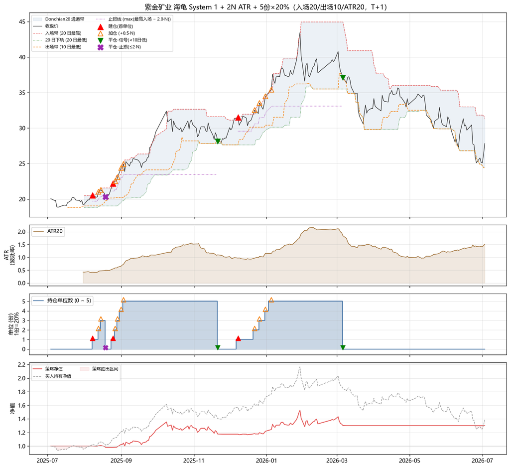

```python
df, stats = run_pipeline(str(CSV_PATH), name="紫金矿业", out_png=str(OUT_PNG))
```

## 7. 所有事件明细（建仓 / 加仓 / 平仓）

```python
events = df[df["event"] != ""].copy()
events["trade_date"] = pd.to_datetime(events["trade_date"]).dt.date
events_table = events[
    ["trade_date", "close", "atr", "units", "stop_loss", "event"]
].rename(columns={
    "trade_date": "日期",
    "close": "收盘价",
    "atr": "ATR(20)",
    "units": "持仓份数",
    "stop_loss": "止损位",
    "event": "事件",
})
events_table.reset_index(drop=True)
```

|  | 日期 | 收盘价 | ATR(20) | 持仓份数 | 止损位 | 事件 |
| --- | --- | --- | --- | --- | --- | --- |
| 0 | 2025-08-08 | 20.54 | 0.4205 | 1 | 19.699 | entry |
| 1 | 2025-08-13 | 21.02 | 0.4535 | 2 | 20.113 | add |
| 2 | 2025-08-15 | 21.29 | 0.4715 | 3 | 20.347 | add |
| 3 | 2025-08-19 | 20.33 | 0.4955 | 0 | NaN | exit_stop |
| 4 | 2025-08-25 | 22.21 | 0.5470 | 1 | 21.116 | entry |
| 5 | 2025-08-27 | 22.53 | 0.5915 | 2 | 21.347 | add |
| 6 | 2025-08-29 | 23.08 | 0.6150 | 3 | 21.850 | add |
| 7 | 2025-09-01 | 24.38 | 0.6595 | 4 | 23.061 | add |
| 8 | 2025-09-03 | 24.94 | 0.7345 | 5 | 23.471 | add |
| 9 | 2025-11-21 | 28.14 | 1.0995 | 0 | NaN | exit_signal |
| 10 | 2025-12-08 | 31.50 | 0.9710 | 1 | 29.558 | entry |
| 11 | 2025-12-22 | 32.53 | 0.9705 | 2 | 30.589 | add |
| 12 | 2025-12-26 | 33.53 | 1.0365 | 3 | 31.457 | add |
| 13 | 2025-12-31 | 34.47 | 1.1565 | 4 | 32.157 | add |
| 14 | 2026-01-05 | 35.40 | 1.1545 | 5 | 33.091 | add |
| 15 | 2026-03-06 | 37.10 | 1.8460 | 0 | NaN | exit_signal |

## 8. 海龟规则合规检查

```python
check_list = [
    ("入场：close > N 日 Donchian 高点（主流程 N=20，shift(1) 防当日内部时序）", True),
    ("加仓：close ≥ 最后入场价 + 0.5·N，单方向 ≤ MAX_UNITS", True),
    ("加仓后止损上移：max(原止损, 最高入场价 − 2·N)，只升不降", True),
    ("平仓-信号：close < 10 日 Donchian 低点", True),
    ("平仓-止损：close ≤ 入场时点的入场价 − 2·N", True),
    ("仓位上限 100%（MAX_UNITS 份 × unit_size），不带杠杆", True),
    ("T+1 开盘价成交（position = signal.shift(1)）", True),
    ("头寸规模（账户 1% 风险反推每份资金）：未启用（你确认不需要）", "未启用"),
]
for item, status in check_list:
    flag = "✓" if status is True else ("· " + str(status))
    print(f"  [{flag}] {item}")
```

```
  [✓] 入场：close > N 日 Donchian 高点（主流程 N=20，shift(1) 防当日内部时序）
  [✓] 加仓：close ≥ 最后入场价 + 0.5·N，单方向 ≤ MAX_UNITS
  [✓] 加仓后止损上移：max(原止损, 最高入场价 − 2·N)，只升不降
  [✓] 平仓-信号：close < 10 日 Donchian 低点
  [✓] 平仓-止损：close ≤ 入场时点的入场价 − 2·N
  [✓] 仓位上限 100%（MAX_UNITS 份 × unit_size），不带杠杆
  [✓] T+1 开盘价成交（position = signal.shift(1)）
  [· 未启用] 头寸规模（账户 1% 风险反推每份资金）：未启用（你确认不需要）
```

## 9. 参数实验：通道 15 日 + 加仓 2 次（MAX_UNITS=3）

主流程通道 20 日、加仓 4 次（MAX_UNITS=5）。这一节把两个常见维度同时调整：

- 通道 20 → 15：更短的 Donchian 周期，突破更敏感
- 加仓 4 次 → 2 次（MAX_UNITS=5 → 3）：保留分批形态但更保守

其余参数（ATR 周期 20 / 出场通道 10 / 止损 2N / 加仓间距 0.5N / 单标的 1.0 资金回测）全部沿用。 输出图只保留价格 + 净值，去掉 ATR 子图和单位数子图——这些只是节奏参考，参数对照时看这两张图最直接。

```
紫金矿业（参数实验） 海龟 System 1 回测
区间：2025-07-04 ~ 2026-07-03（242 个交易日，年化因子 = 252）
============================================================
[累计回报 (Cumulative Return)]
  期末净值 NAV_final   = 1.3062
  期初净值 NAV_initial = 1.0000
  累计回报 = NAV_final / NAV_initial − 1 = 1.3062 / 1.0000 − 1 = 30.62%

[夏普比率 (Sharpe Ratio)]
  日均收益 μ_d  = 0.1310%
  日收益标准差 σ = 2.0374%
  夏普 = (μ_d / σ) × √252 = 0.1310% / 2.0374% × √252 = 1.02
  年化收益 (1+total)^(252/N)−1 = 32.07%
  年化波动 σ × √252 = 32.34%

[最大回撤 (Max Drawdown)]
  历史最高点（段起点）: 2026-01-29
  最大回撤点（段末点）: 2026-04-29
  最大回撤 = NAV_末 / NAV_始 − 1 = -18.59%

[仓位结构 / 出场分类]
  建仓次数: 4
  加仓次数: 7
  信号清仓次数: 3
  止损清仓次数: 1

============================================================
[核心指标 - Final]
  累计回报 (Cumulative Return) : 30.62%
  夏普比率  (Sharpe Ratio)     : 1.02
  最大回撤 (Max Drawdown)      : -18.59%
============================================================
```

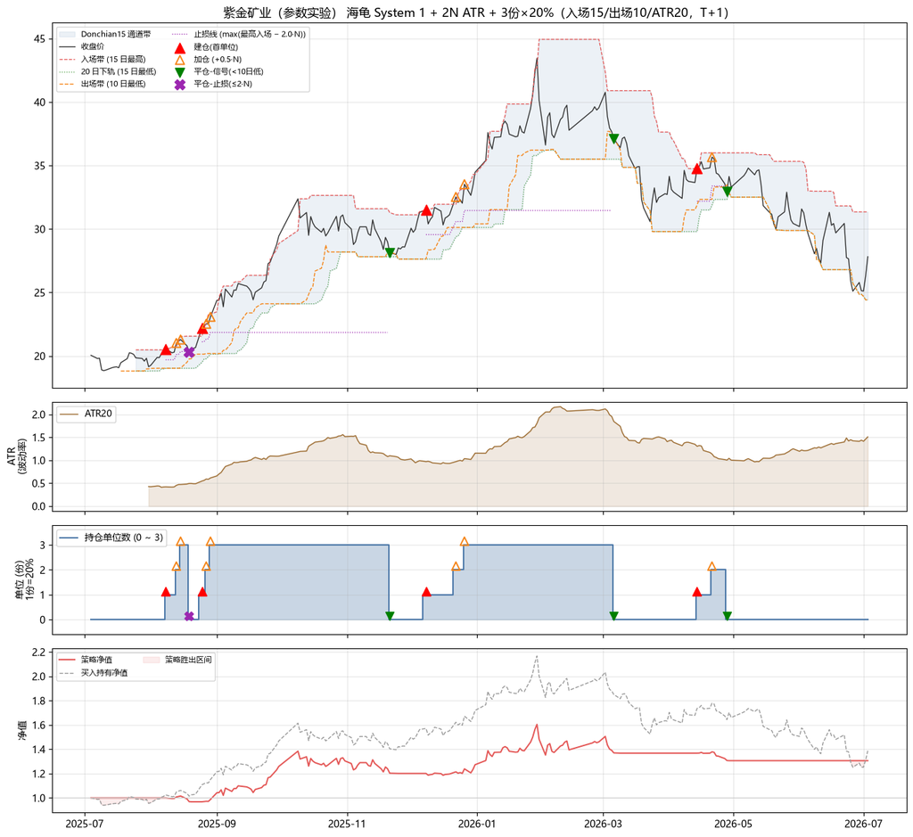

```python
# 实验参数
ENTRY_N_EXP = 15               # 通道 20 → 15
MAX_UNITS_EXP = 3              # 5 → 3（初始 1 + 加仓 2 = 3 份）
UNIT_SIZE_EXP = 1 / MAX_UNITS_EXP  # 每份 33.3%，整体仓位不超过 100%

# 用同套函数，参数 override
df2, stats2 = run_pipeline(
    str(CSV_PATH),
    name="紫金矿业（参数实验）",
    out_png=None,                   # 主版已经出过图，实验版先不出
    entry_n=ENTRY_N_EXP,
    max_units=MAX_UNITS_EXP,
    unit_size=UNIT_SIZE_EXP,
)
```

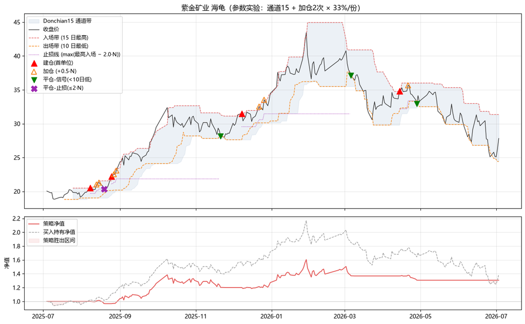

```python
def plot_essential(df, entry_n, exit_n, atr_mult, max_units,
                     add_trigger, unit_size, out_path, name):
    # 两面板: 价格 + 通道 + 事件 / 净值. 去掉 ATR 和单位数子图
    fig, (ax1, ax2) = plt.subplots(
        2, 1, figsize=(13, 8), sharex=True,
        gridspec_kw={"height_ratios": [2.5, 1.2]},
    )

    # 价格 + Donchian + 事件
    ax1.fill_between(df["trade_date"], df["lower_full"], df["upper_entry"],
                     color="#4c78a8", alpha=0.10,
                     label=f"Donchian{entry_n} 通道带")
    ax1.plot(df["trade_date"], df["close"], label="收盘价", color="#333", lw=1)
    ax1.plot(df["trade_date"], df["upper_entry"],
             label=f"入场带 ({entry_n} 日最高)",
             color="#e45756", lw=0.9, ls="--")
    ax1.plot(df["trade_date"], df["lower_exit"],
             label=f"出场带 ({exit_n} 日最低)",
             color="#f58518", lw=1.0, ls="--")
    ax1.plot(df["trade_date"], df["stop_loss"],
             label=f"止损线 (max(最高入场 − {atr_mult}·N))",
             color="#9c27b0", lw=0.9, ls=":")

    e_entry = df[df["event"] == "entry"]
    e_add = df[df["event"] == "add"]
    e_exit_signal = df[df["event"] == "exit_signal"]
    e_exit_stop = df[df["event"] == "exit_stop"]

    ax1.scatter(e_entry["trade_date"], e_entry["close"], marker="^", color="red",
                s=110, label="建仓(首单位)", zorder=5)
    ax1.scatter(e_add["trade_date"], e_add["close"], marker="^", facecolors="none",
                edgecolors="#f58518", s=80, linewidths=1.4,
                label=f"加仓 (+{add_trigger}·N)", zorder=5)
    ax1.scatter(e_exit_signal["trade_date"], e_exit_signal["close"], marker="v",
                color="green", s=90, label="平仓-信号(<10日低)", zorder=5)
    ax1.scatter(e_exit_stop["trade_date"], e_exit_stop["close"], marker="X",
                color="#9c27b0", s=110, label="平仓-止损(≤2·N)", zorder=5)
    ax1.set_title(
        f"{name} 海龟（参数实验：通道{entry_n} + 加仓{max_units-1}次 × {unit_size:.0%}/份）"
    )
    ax1.legend(loc="upper left", fontsize=9)
    ax1.grid(alpha=0.3)

    # 净值
    ax2.plot(df["trade_date"], df["nav_strategy"],
             label="策略净值", color="#e45756", lw=1.4)
    ax2.plot(df["trade_date"], df["nav_buy_hold"],
             label="买入持有净值", color="#999", lw=1, ls="--")
    ax2.axhline(1.0, color="#ccc", lw=0.8)
    ax2.fill_between(df["trade_date"], df["nav_buy_hold"], df["nav_strategy"],
                     where=df["nav_strategy"] >= df["nav_buy_hold"],
                     color="#e45756", alpha=0.10, label="策略胜出区间")
    ax2.set_ylabel("净值")
    ax2.legend(loc="upper left", fontsize=9)
    ax2.grid(alpha=0.3)

    plt.tight_layout()
    if out_path is not None:
        fig.savefig(out_path, dpi=150, bbox_inches="tight")
    plt.show()


plot_essential(
    df2,
    ENTRY_N_EXP, EXIT_N, ATR_MULT, MAX_UNITS_EXP,
    ADD_TRIGGER, UNIT_SIZE_EXP,
    out_path=str(OUT_PNG_EXP),
    name="紫金矿业",
)
```

```python
compare_keys = ["累计回报", "买入持有回报", "年化收益", "年化波动",
                 "夏普比率", "最大回撤",
                 "建仓次数", "加仓次数", "信号清仓次数", "止损清仓次数"]

cmp = pd.DataFrame(
    {
        "主版 通道20+MAX_UNITS=5": {k: stats[k] for k in compare_keys},
        "实验 通道15+MAX_UNITS=3": {k: stats2[k] for k in compare_keys},
    }
).T

# 把百分比格式的指标分开打印（避免混排）
print("[百分比类]")
for k in ["累计回报", "买入持有回报", "年化收益", "年化波动", "最大回撤"]:
    a, b = cmp.at["主版 通道20+MAX_UNITS=5", k], cmp.at["实验 通道15+MAX_UNITS=3", k]
    print(f"  {k:<10}  主版={a:.2%}    实验={b:.2%}    差={b-a:+.2%}")

print("[无量纲指标]")
for k in ["夏普比率"]:
    a, b = cmp.at["主版 通道20+MAX_UNITS=5", k], cmp.at["实验 通道15+MAX_UNITS=3", k]
    print(f"  {k:<10}  主版={a:.2f}    实验={b:.2f}    差={b-a:+.2f}")

print("[仓位事件]")
for k in ["建仓次数", "加仓次数", "信号清仓次数", "止损清仓次数"]:
    a, b = cmp.at["主版 通道20+MAX_UNITS=5", k], cmp.at["实验 通道15+MAX_UNITS=3", k]
    print(f"  {k:<10}  主版={int(a)}    实验={int(b)}    差={int(b)-int(a):+d}")
cmp
```

```
[百分比类]
  累计回报        主版=30.17%    实验=30.62%    差=+0.45%
  买入持有回报      主版=38.75%    实验=38.75%    差=+0.00%
  年化收益        主版=31.59%    实验=32.07%    差=+0.48%
  年化波动        主版=31.20%    实验=32.34%    差=+1.14%
  最大回撤        主版=-15.74%    实验=-18.59%    差=-2.85%
[无量纲指标]
  夏普比率        主版=1.04    实验=1.02    差=-0.01
[仓位事件]
  建仓次数        主版=3    实验=4    差=+1
  加仓次数        主版=10    实验=7    差=-3
  信号清仓次数      主版=2    实验=3    差=+1
  止损清仓次数      主版=1    实验=1    差=+0
```

|  | 累计回报 | 买入持有回报 | 年化收益 | 年化波动 | 夏普比率 | 最大回撤 | 建仓次数 | 加仓次数 | 信号清仓次数 | 止损清仓次数 |
| --- | --- | --- | --- | --- | --- | --- | --- | --- | --- | --- |
| 主版 通道20+MAX_UNITS=5 | 0.301672 | 0.387531 | 0.315931 | 0.312022 | 1.035391 | -0.157422 | 3.0 | 10.0 | 2.0 | 1.0 |
| 实验 通道15+MAX_UNITS=3 | 0.306196 | 0.387531 | 0.320694 | 0.323424 | 1.021067 | -0.185949 | 4.0 | 7.0 | 3.0 | 1.0 |